# EXPLORATION OF WHITE WINE QUALITY by LAWRENCE V. SUMERA

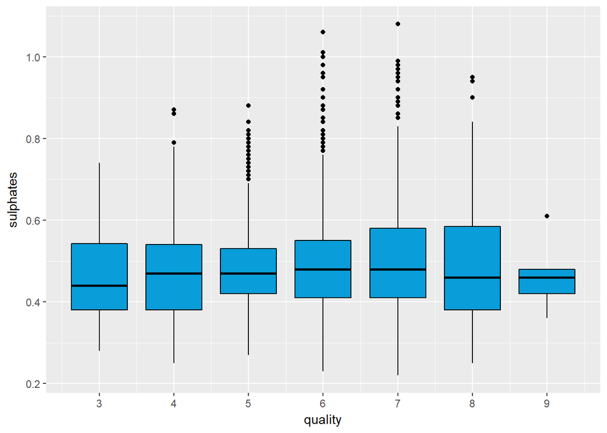

Sulfur and its derivatives are needed because they function as antimicrobial and antioxidant agents. There seems to be a right amount of these which would result to an excellent wine quality. These wines tend to have a relatively low total sulfur dioxide content than the rest. Higher amounts are known to be evident in their smell and taste. Since sulfur dioxide levels may affect quality, I want to see the plot.

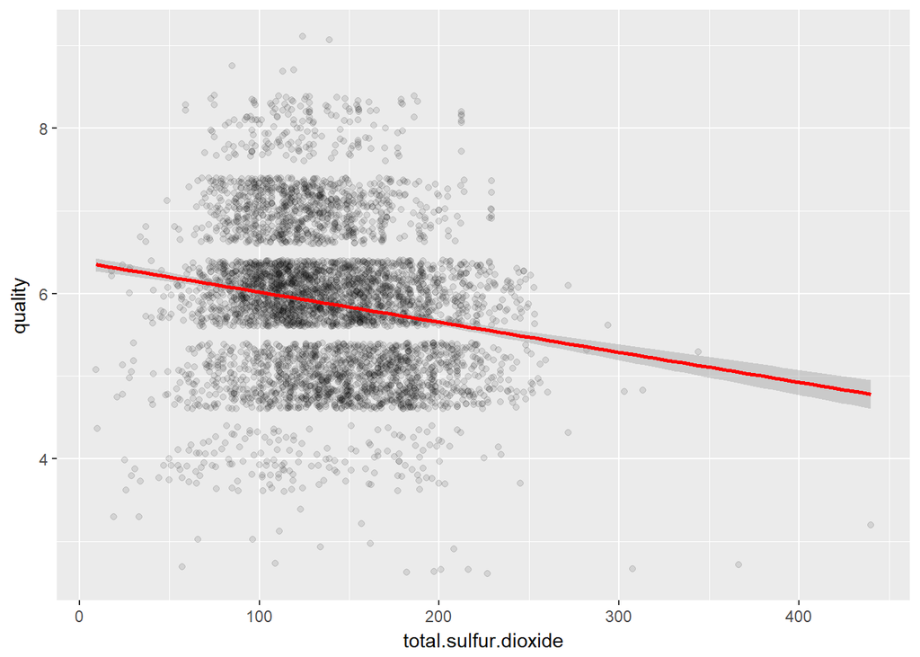

The plot confirms that higher total sulfur dioxide levels may decrease the quality of wine. Total sulfur dioxide is just the sum of free sulfur dioxide and bound sulfur dioxide, so it does not make sense to plot free sulfur dioxide too. I can check the relationship between total sulfur dioxide and sulphates.

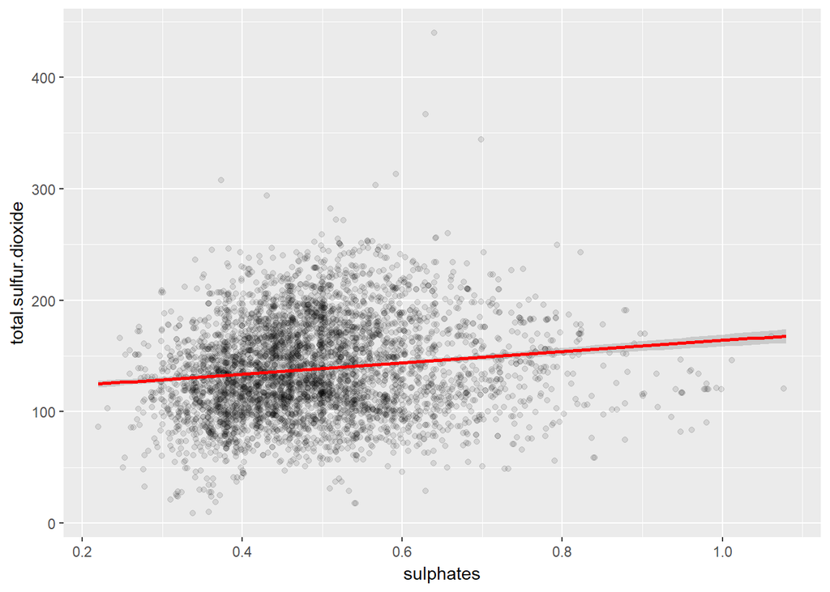

Surprisingly, there is no strong linear relationship between sulphates and total sulfur dioxide even though sulphates cause the sulfur dioxide levels to rise. The sulphates variable refers to the wine antimicrobial and antioxidant additive so total sulfur dioxide levels is just the result of it. There must be another relationship to describe them which can be answered by higher chemistry courses. It is also worth exploring that more sulfur dioxide is needed if there are higher amounts of sugar because sugar is susceptible to attack by microorganisms which would cause a restart of fermentation.

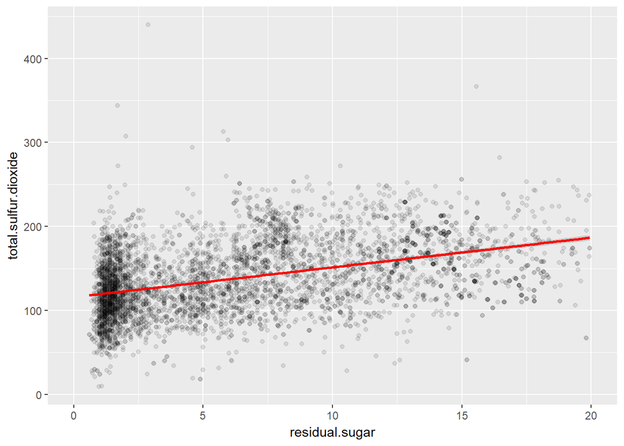

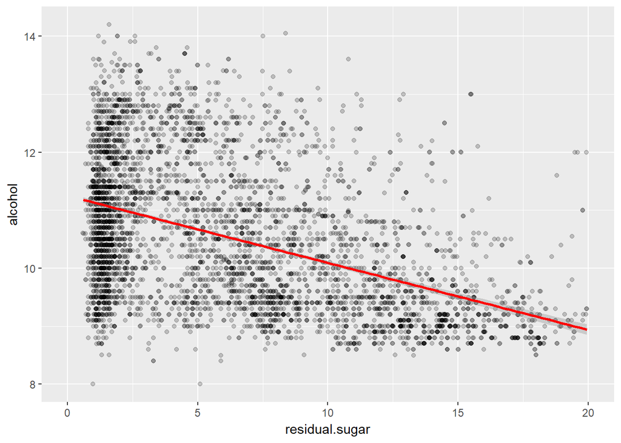

During the process of fermentation, yeast typically converts all the sugar into alcohol. The amount of sugar remaining after fermentation stops is this residual sugar. Thus, it is expected that as residual sugar increases, alcohol content decreases.

The final surprise is the effect of chlorides (or salt) on wine quality. I was not expecting any relationship between them. The scatter plot and box plots proved me wrong.

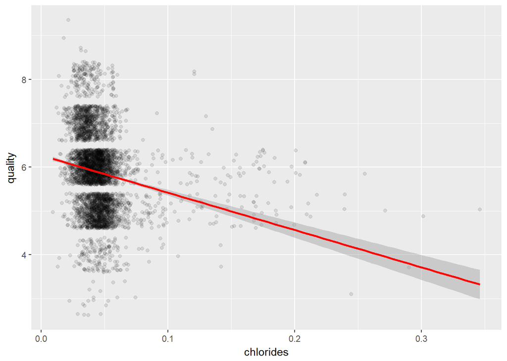

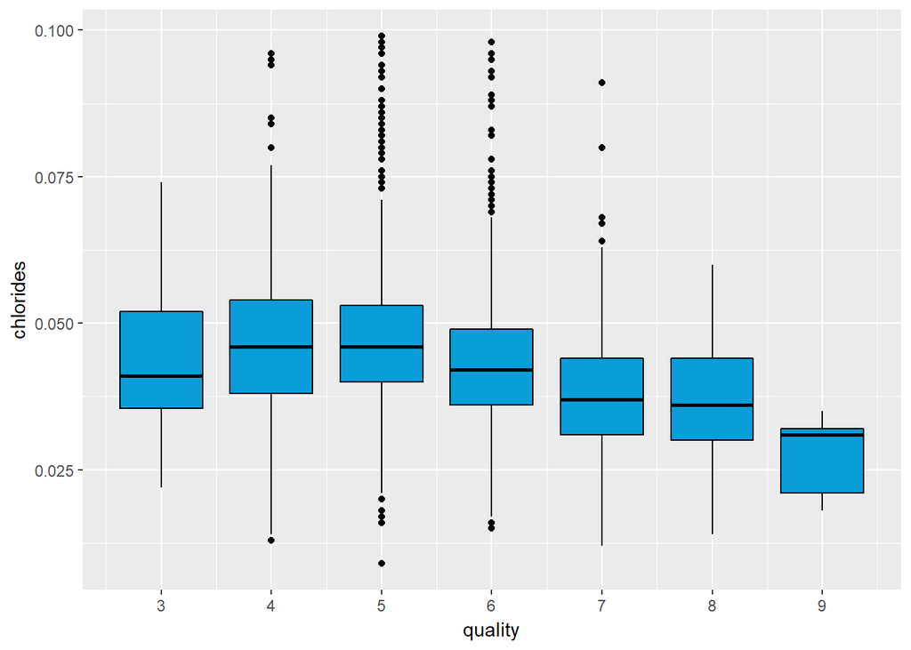

I can see clearly that higher quality wines have lower chlorides. I also know that the lesser the amount of chlorides, the lighter the wine is. So chlorides also affects density.

# Bivariate Analysis

### Talk about some of the relationships you observed in this part of the investigation. How did the feature(s) of interest vary with other features in the dataset?

Quality correlates moderately with alcohol content and correlates slightly with chlorides.

As the percent alcohol content of the wine increases, the variance in quality increases. The relationship between quality and alcohol appears linear. This is also true for the amount of chlorides. However, as the chlorides increases, the quality decreases.

Based on the R^2 value, alcohol explains about 19% of the variance in quality. Chlorides account for only 4.4%. Other features of interest can be incorporated into the model to explain the variance in quality.

High levels of volatile acidity may decrease the quality of the wine since it indicates the level of acetic acid. Higher acetic acid levels lead to an unpleasant, vinegar taste. Sulfur dioxide is important in wines since they act as antimicrobial and antioxidant agents. Too much however, can also cause a decrease in the quality.

### Did you observe any interesting relationships between the other features (not the main feature(s) of interest)?

The bivariate analysis not only showed the relationships between quality against a chemical property of wine but also showed the relationships among these properties. The most notable correlation is between alcohol and density. The higher the percent alcohol by volume, the lower the density. Residual sugar also strongly affects the density. The higher the sugar content, the higher the density.

Other correlations involve pH and the total acid content. As acid content increases, the pH decreases. Another moderate correlation is between residual sugar and total sulfur dioxide since more sulfur dioxide is needed when there is more sugar.

### What was the strongest relationship you found?

The quality of the wine is positively correlated with percent alcohol by volume. Another variable, chlorides content, correlate with the quality but much less than alcohol. Alcohol can be used in a model to predict the quality of wine. However, alcohol may tend to influence or get influenced with the other attributes so it is worth exploring further into the next section on multivariate analysis to accurately build an accurate model.

# Multivariate Plots Section

I want to start where I stopped from the bivariate analysis. Since alcohol content had the strongest relationship with quality, I want to use it as my main variable along with some attributes to check their influence. First, four buckets for total acid content will be created. The boundaries will be based on the four quartiles. These buckets will be plotted against the quality versus alcohol variables to compare if the total acid content can affect quality.

```
##    Min. 1st Qu.  Median    Mean 3rd Qu.    Max.
##   4.130   6.890   7.405   7.467   7.960  14.960
```

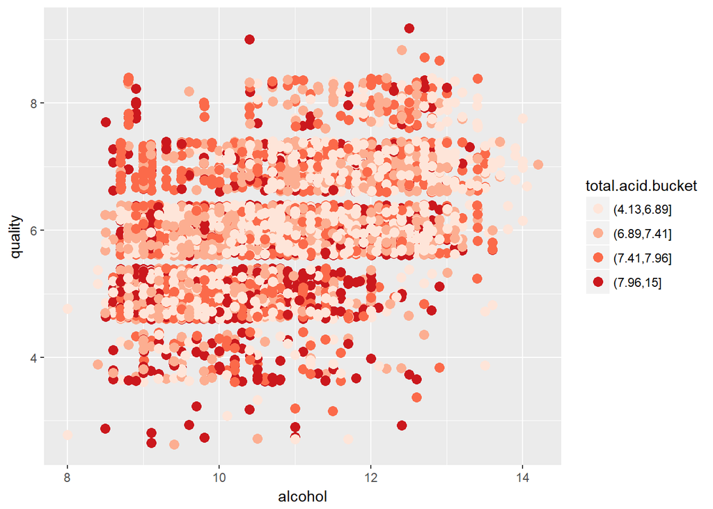

The plot looks noisy and it is difficult to extract any relationship from it. The colors are scattered all over the graph and there is no clear trend on how total acid affects quality. I will use a line graph on my next plot and see if it improves.

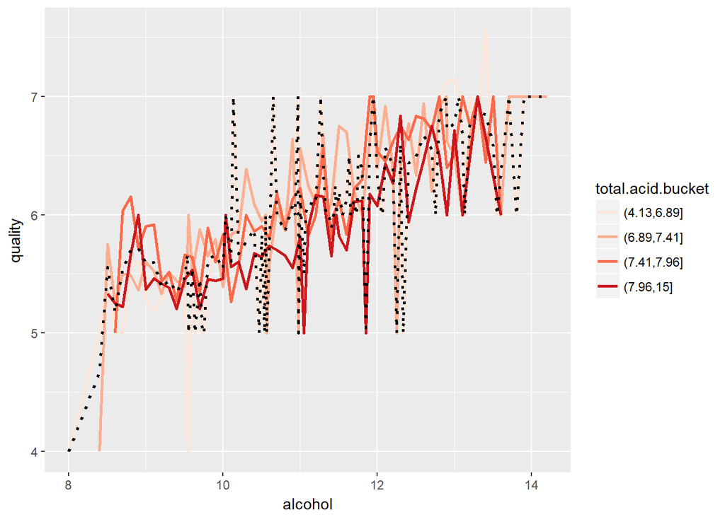

It might even look worse than the first plot. Similar to the first plot, the lines overlap and there is no apparent differentiation. This plot will no longer be used in the subsequent plots. I will try to use a smooth line on my next plot and see if it improves.

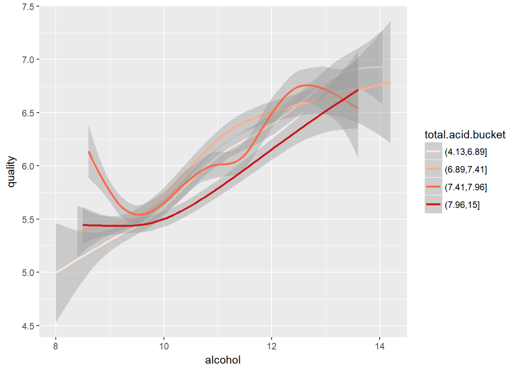

Among the three, this looks the best. The first two plots suffer from overplotting like what I saw in the earlier analysis. These smooth lines let me see the patterns. I can see that the lowest amounts of acid may have the highest quality at higher alcohol contents. It also has the lowest quality at lower alcohol contents. From this plot, it can be inferred that higher alcohol content with low total acid offer the best qualities. I will check pH next.

```
##    Min. 1st Qu.  Median    Mean 3rd Qu.    Max.
##   2.720   3.090   3.180   3.188   3.280   3.820
```

It would not be advisable to plot the pH anymore since the values are close to each other. I have also previously proven the moderate correlation between pH and total acid so the trend would also apply. I will then proceed with plotting the amount of residual sugar using the same methods as above.

```
##    Min. 1st Qu.  Median    Mean 3rd Qu.    Max.
##   0.600   1.700   5.200   6.391   9.900  65.800
```

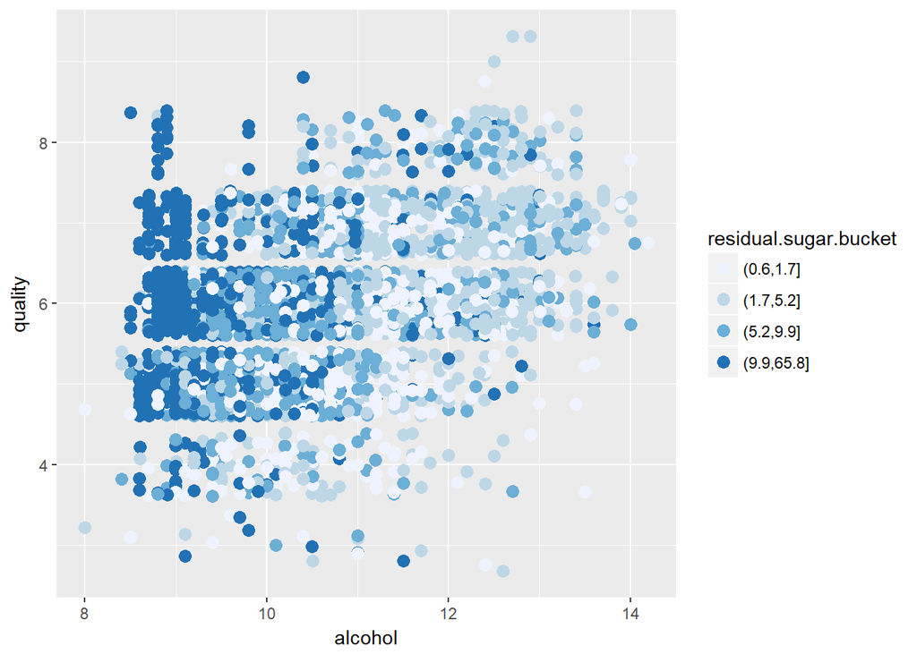

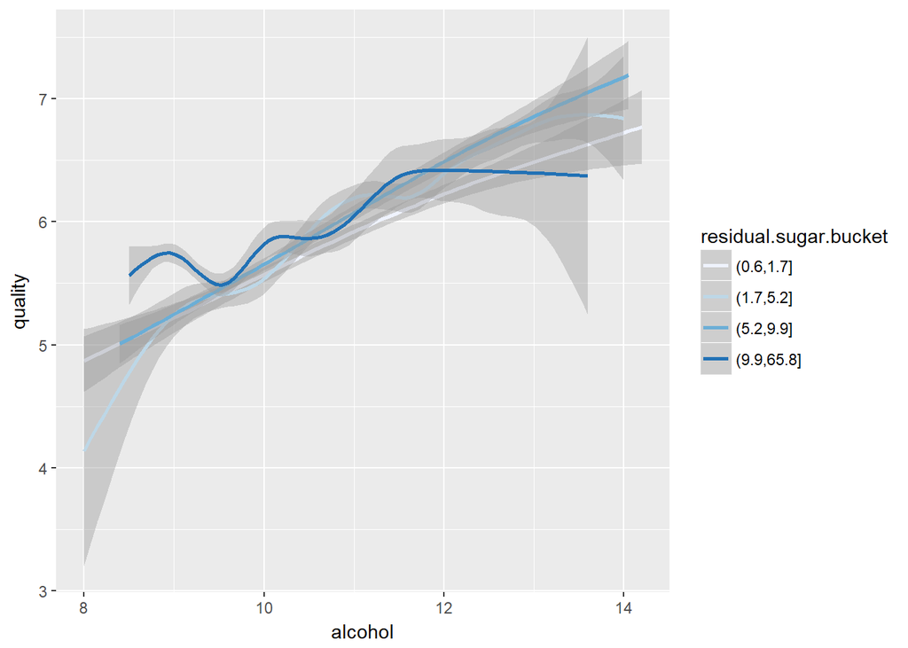

For this pair of plots, the first plot looks better since it clearly shows that the greater amounts of residual sugar have the lower alcohol content. It was interesting to see that at this high sugar levels, there were also high quality wines present even though it had lower percent alcohol. Residual sugar has an effect on the alcohol level but not on the quality. However, since higher alcohol leads to better qualities, it is safer to decrease sugar levels to increase the alcohol levels. For the next plot, I suspect that chlorides will show a similar trend.

```
##    Min. 1st Qu.  Median    Mean 3rd Qu.    Max.
## 0.00900 0.03600 0.04300 0.04577 0.05000 0.34600
```

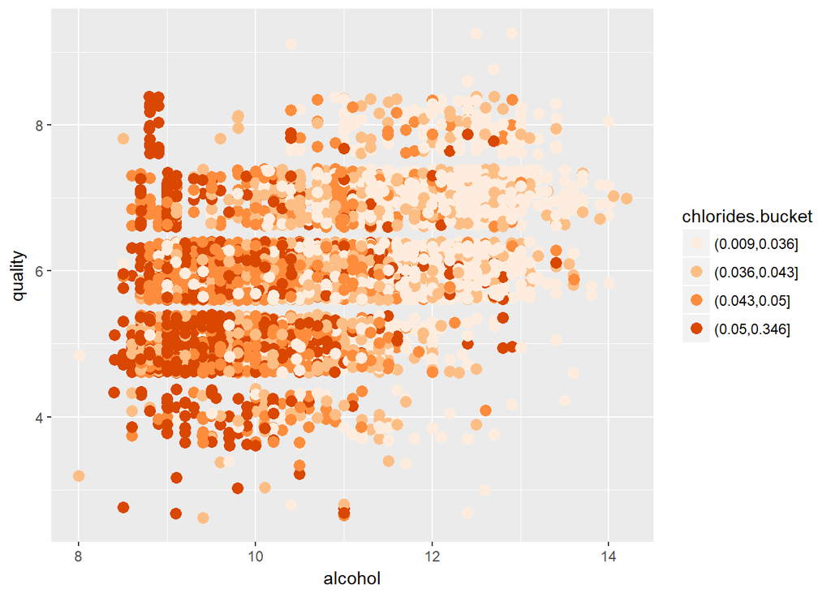

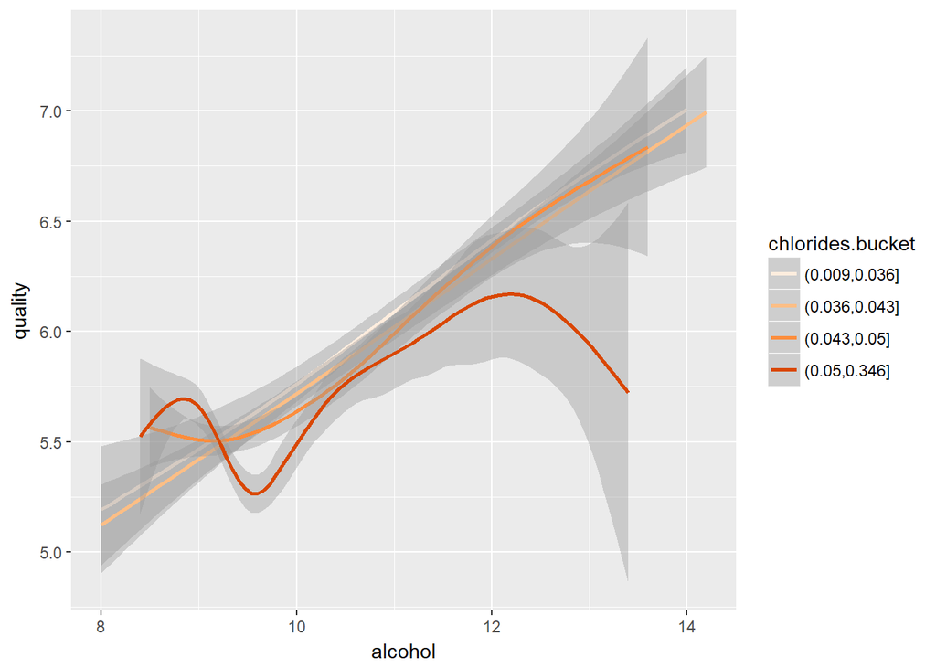

True enough, the first plot resembles the residual sugar. The difference is that lower amounts of chloride are now visible in the higher quality range. The relationship between quality and chlorides is more pronounced than between residual sugar and quality. On the other hand, it shows a weaker relationship with alcohol since the higher amounts of chlorides are more dispersed than clustered in the lower alcohol range. Finally, I want to explore sulfur content.

```
##    Min. 1st Qu.  Median    Mean 3rd Qu.    Max.
##     9.0   108.0   134.0   138.4   167.0   440.0
```

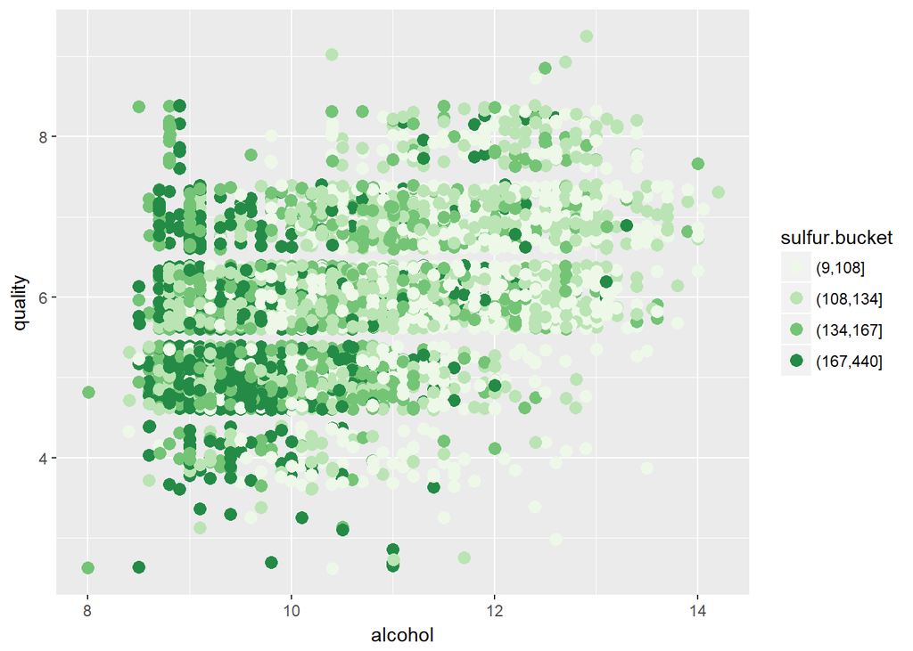

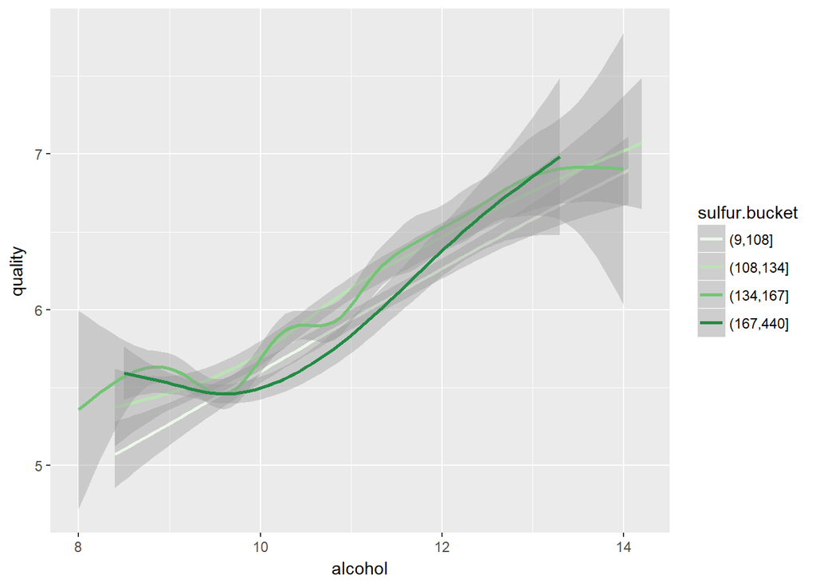

Again, the first plot resembles the residual sugar and chlorides. Similarly, lower amounts of sulfur are also visible in the higher quality range. The relationship between sulfur and quality is more or less the same magnitude as for chlorides.

The relationship with alcohol is inversely proportional for the three previous variables: residual sugar, chlorides, and total sulfur dioxide. Using the knowledge I gained from the analysis presented above, it is now time to produce a model which could predict the quality of the wine based on some of the attributes.

```
##
## Calls:
## m1: lm(formula = quality ~ alcohol, data = wq)
## m2: lm(formula = quality ~ alcohol + volatile.acidity, data = wq)
## m3: lm(formula = quality ~ alcohol + volatile.acidity + residual.sugar,
##     data = wq)
## m4: lm(formula = quality ~ alcohol + volatile.acidity + residual.sugar +
##     free.sulfur.dioxide, data = wq)
## m5: lm(formula = quality ~ alcohol + volatile.acidity + residual.sugar +
##     free.sulfur.dioxide + fixed.acidity, data = wq)
## m6: lm(formula = quality ~ alcohol + volatile.acidity + residual.sugar +
##     free.sulfur.dioxide + fixed.acidity + sulphates, data = wq)
##
## ===========================================================================================================
##                             m1            m2            m3            m4            m5            m6
## -----------------------------------------------------------------------------------------------------------
##   (Intercept)              2.582***      3.017***      2.356***      2.134***      2.663***      2.446***
##                           (0.098)       (0.098)       (0.114)       (0.119)       (0.157)       (0.164)
##   alcohol                  0.313***      0.324***      0.375***      0.382***      0.377***      0.378***
##                           (0.009)       (0.009)       (0.010)       (0.010)       (0.010)       (0.010)
##   volatile.acidity                      -1.979***     -2.107***     -2.035***     -2.052***     -2.040***
##                                         (0.110)       (0.109)       (0.109)       (0.109)       (0.109)
##   residual.sugar                                       0.027***      0.023***      0.024***      0.025***
##                                                       (0.002)       (0.002)       (0.002)       (0.002)
##   free.sulfur.dioxide                                                0.004***      0.004***      0.004***
##                                                                     (0.001)       (0.001)       (0.001)
##   fixed.acidity                                                                   -0.068***     -0.067***
##                                                                                   (0.013)       (0.013)
##   sulphates                                                                                      0.412***
##                                                                                                 (0.095)
## -----------------------------------------------------------------------------------------------------------
##   R-squared                0.190         0.240         0.259         0.264         0.268         0.271
##   adj. R-squared           0.190         0.240         0.258         0.263         0.267         0.270
##   sigma                    0.797         0.772         0.763         0.760         0.758         0.757
##   F                     1146.395       773.875       568.789       438.761       358.264       302.773
##   p                        0.000         0.000         0.000         0.000         0.000         0.000
##   Log-likelihood       -5839.391     -5681.776     -5622.083     -5603.956     -5590.495     -5581.099
##   Deviance              3112.257      2918.264      2847.993      2826.991      2811.494      2800.729
##   AIC                  11684.782     11371.552     11254.166     11219.912     11194.989     11178.199
##   BIC                  11704.272     11397.538     11286.649     11258.891     11240.465     11230.172
##   N                     4898          4898          4898          4898          4898          4898
## ===========================================================================================================
```

```
##
## Call:
## lm(formula = quality ~ alcohol + volatile.acidity + residual.sugar +
##     free.sulfur.dioxide + fixed.acidity + sulphates, data = wq)
##
## Residuals:
##     Min      1Q  Median      3Q     Max
## -3.8430 -0.5040 -0.0330  0.4563  3.2337
##
## Coefficients:
##                      Estimate Std. Error t value Pr(>|t|)
## (Intercept)          2.446197   0.164239  14.894  < 2e-16 ***
## alcohol              0.377826   0.010031  37.666  < 2e-16 ***
## volatile.acidity    -2.040210   0.108872 -18.740  < 2e-16 ***
## residual.sugar       0.024531   0.002474   9.918  < 2e-16 ***
## free.sulfur.dioxide  0.003574   0.000681   5.247 1.61e-07 ***
## fixed.acidity       -0.066828   0.012982  -5.148 2.74e-07 ***
## sulphates            0.412259   0.095082   4.336 1.48e-05 ***
## ---
## Signif. codes:  0 '***' 0.001 '**' 0.01 '*' 0.05 '.' 0.1 ' ' 1
##
## Residual standard error: 0.7567 on 4891 degrees of freedom
## Multiple R-squared:  0.2708, Adjusted R-squared:  0.2699
## F-statistic: 302.8 on 6 and 4891 DF,  p-value: < 2.2e-16
```

I noticed that volatile acidity was included instead of total acid. Looking back at the correlation matrix, I can see that volatile acidity has a higher correlation than total acid (shown below) so it makes sense that this attribute is included. Also, sulphates was included instead of chlorides. It is most likely that not all the sulphates converted to sulfur dioxide so they are all that remain.

```
##
##  Pearson's product-moment correlation
##
## data:  total.acid and quality
## t = -9.273, df = 4896, p-value < 2.2e-16
## alternative hypothesis: true correlation is not equal to 0
## 95 percent confidence interval:
##  -0.1587994 -0.1037525
## sample estimates:
##        cor
## -0.1313772
```

# Multivariate Analysis

### Talk about some of the relationships you observed in this part of the investigation. Were there features that strengthened each other in terms of looking at your feature(s) of interest?

The mathematical model shows that the attributes which affect the quality are the following: alcohol, volatile acidity, residual sugar, free sulfur dioxide, fixed acidity and sulphates. These are not completely identical to what was explored in the analysis.

### Were there any interesting or surprising interactions between features?

It was interesting to see the interactions between the features. The correlation matrix provided the framework to explore the relationships between the attributes. However, not all the variables explored made it into the model. Even though chlorides had a higher correlation with sulphates than alcohol, it was less significant in predicting the quality when the rest of the attributes were included.

### OPTIONAL: Did you create any models with your dataset? Discuss the strengths and limitations of your model.

The variables in the linear model account for only 27.1% of the variance in quality. Alcohol and volatile acidity contributed 19% and 5%, respectively. The addition of the four other variables to the model improved the R^2 value by a total of 3.1% only.

The model eliminates the possible collinearity among variables like alcohol with density and free sulphur dioxide with total sulphur dioxide. The model only accounting for 27.1 % may mean other factors not present in the dataset may explain the quality.

# Final Plots and Summary

### Plot One

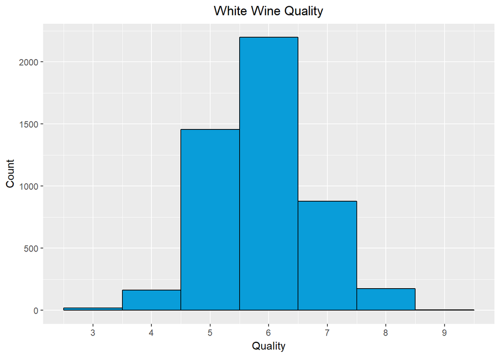

### Plot Two

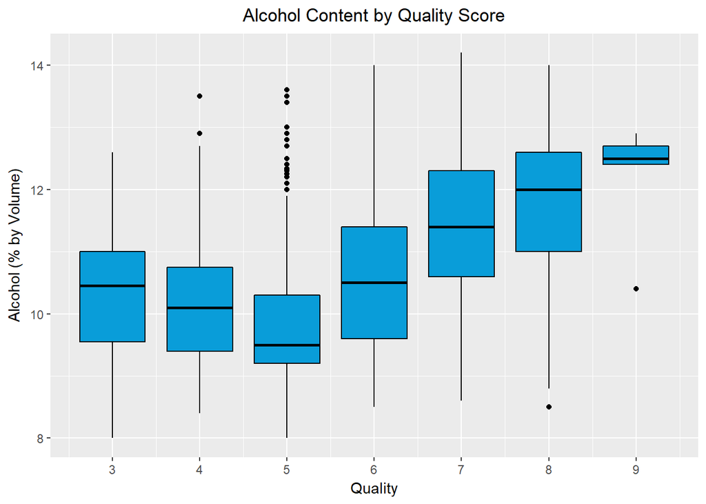

### Description Two

The higher quality white wines contain the largest median alcohol content. The wine with the lowest median alcohol content has a quality score of 5. For white wines with a quality score above 6, the median alcohol content is increasing.

### Plot Three

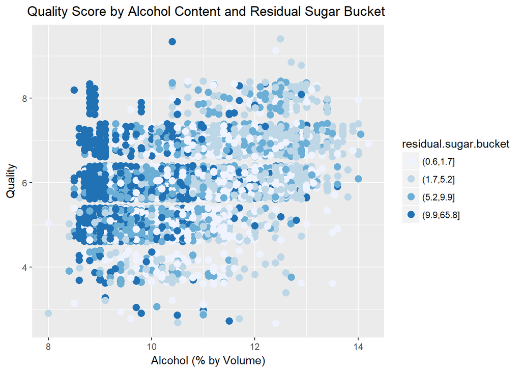

# Reflection

The white wines data set contains information on 4,898 white wines across 11 input variables (which are based on physicochemical tests). There is one output variable called the quality score which is the median of at least 3 evaluations made by wine experts. I started by creating histograms to understand the individual variables in the data set and checking their distributions. Then, I explored the relationships among the variables and created scatterplots and box plots to visualize then. Finally, I discovered the the quality of white wine across some of the attributes and created a linear model to predict white wine quality.

There was a clear positive trend between the alcohol content of the white wine and its quality. The moderate correlation value justified the trend. I expected that some of the attributes would be correlated such as density & alcohol, and total acid & pH. I was surprised that residual sugar and alcohol were also related. I then learned that during fermentation, sugar is converted into alcohol but not all, so they become the residue. I struggled understanding how total sulfur dioxide and sulphates were not related, and this would be best explained by higher levels of chemistry. For the linear model, not all attributes were significant as expected. Alcohol content, volatile acidity, residual sugar, free sulfur dioxide, fixed acidity and sulphates accounted for 27.1% of the variance in the quality.

One of the limitations of the model is the inherent bias of the quality since it only a median of at least 3 evaluations by wine experts. The more popular wines may have been evaluated by more than 3 experts and I would not know. Also, there is no information on how the evaluations were made. Since the linear model only accounted for much less than 30% of the quality, it would be interesting to include other attributes such as age and viscosity and check how much they affect the quality, if they did. To investigate the dataset further, I would also include the grape types, wine brands and wine selling prices if issues of privacy and logistics were to be resolved. It would then help us understand white wine quality and how to select the best ones.

I created this project expecting to find out which attributes affect white wine quality. What I discovered was the importance of looking at each attribute and checking if they are highly correlated with each other. It is not enough to blindly create a mathematical model and conclude that it is the best. Every angle needs to be examined and this is where domain knowledge helps. The absence however, would mean more hours spent on research but the satisfaction that comes with exploring the data, understanding the concepts and visualizing the results is worth the efforts put in.